# Bike Rental Analysis

Sam Skinner

12/3/2016

### Executive Summary

Bike Rentals are a growing industry but one that faces both weather-based and seasonal variations in demand. It is important to quantify how those those variations affect demand as demand, in turn, affects the number of employees needed as well as the number of bikes that need to be available. Significant mis-matches in bike availability or numbers of workers can result in missing rental opportunities (no bike available or insufficient employees for timely rental) or conversely, extra expenses to the rental company in terms of wages or bike purchases.

Using a publicly available dataset (described below), I attempt to answer two basic questions:

Q1: What are the factors that determine demand?

Q2: Do these factors vary by season?

The dataset consists of 17379 rental records collected over a two year period (2011, 2012) in Washington, D.C.. The records have been aggregated into 731 days for this analysis because each day is the determinant of the number bikes and employees needed.

Data attributes are both categorical and numerical and the statistical analyses vary accordingly.

##### The Data Source

The data are taken from the UCI Machine Learning Repository. The original data are reported and analyized in a paper by Fanaee, T and Gama, J.

### Viewing the Data

As noted previously, the data consist of 731 day records with 15 variables per record plus a record number. Below is a list of the data attributes, including the variable name the type of data and a sample of the first 10 records for that attribute:

```r
day <- read.csv('day.csv')
str(day)
```

```
## 'data.frame':    731 obs. of  16 variables:
##  $ instance  : int  1 2 3 4 5 6 7 8 9 10 ...
##  $ date      : Factor w/ 731 levels "1/1/11","1/1/12",..: 1 23 45 51 53 55 57 59 61 3 ...
##  $ season    : int  1 1 1 1 1 1 1 1 1 1 ...
##  $ year      : int  0 0 0 0 0 0 0 0 0 0 ...
##  $ month     : int  1 1 1 1 1 1 1 1 1 1 ...
##  $ holiday   : int  0 0 0 0 0 0 0 0 0 0 ...
##  $ weekday   : int  6 0 1 2 3 4 5 6 0 1 ...
##  $ workingday: int  0 0 1 1 1 1 1 0 0 1 ...
##  $ conditions: int  2 2 1 1 1 1 2 2 1 1 ...
##  $ temp      : num  0.344 0.363 0.196 0.2 0.227 ...
##  $ felt_temp : num  0.364 0.354 0.189 0.212 0.229 ...
##  $ hum       : num  0.806 0.696 0.437 0.59 0.437 ...
##  $ windspeed : num  0.16 0.249 0.248 0.16 0.187 ...
##  $ casual    : int  331 131 120 108 82 88 148 68 54 41 ...
##  $ registered: int  654 670 1229 1454 1518 1518 1362 891 768 1280 ...
##  $ count     : int  985 801 1349 1562 1600 1606 1510 959 822 1321 ...
```

#### Visuals

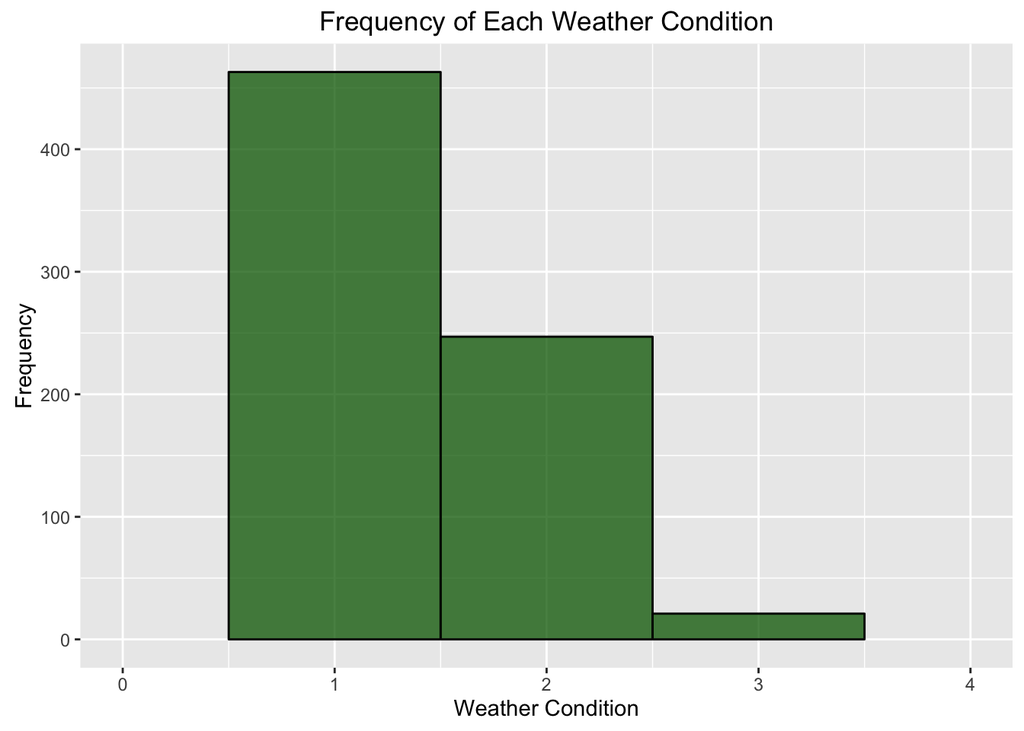

#### Notice that there are no “4” values and very few “3” values (n= 21). In other words, we generally have sunny or partially cloudy days.

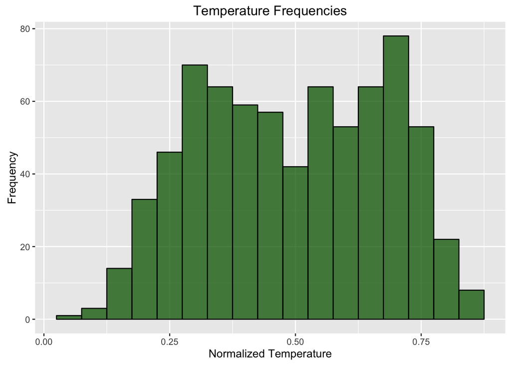

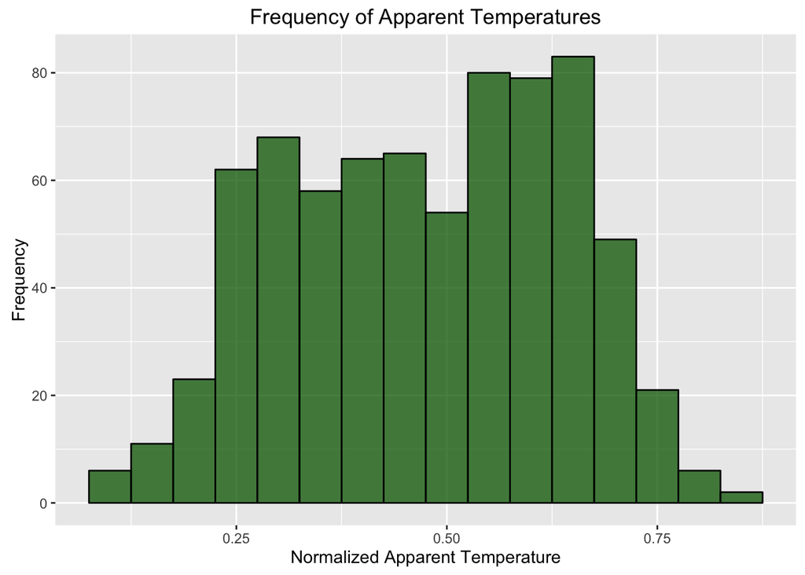

#### Both distributions are platykurtic.

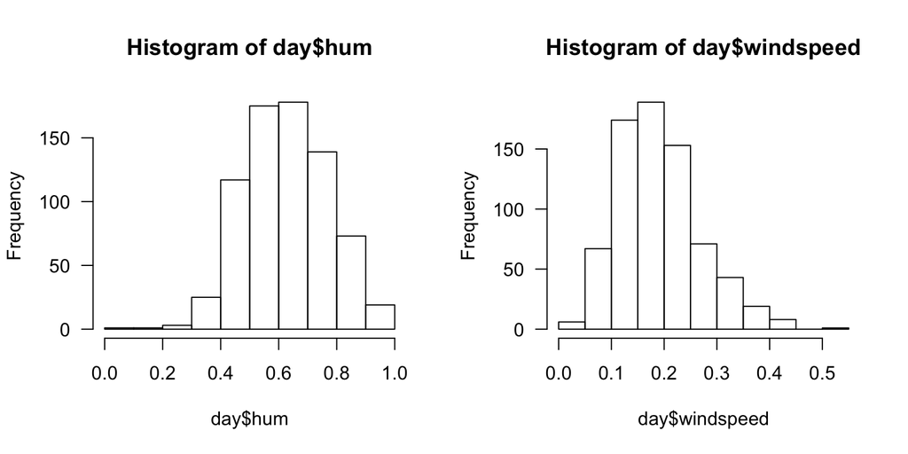

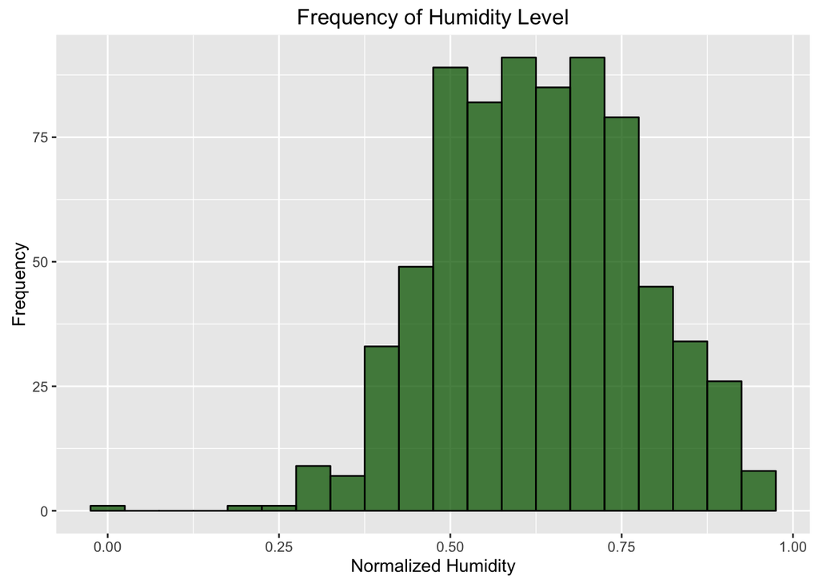

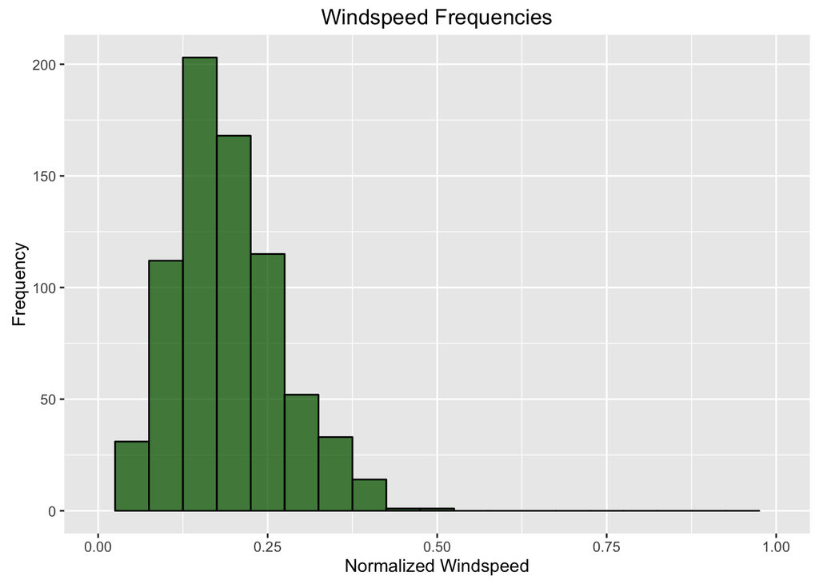

```r
par(mfrow=c(1,2), las=1)
for(i in 1:2) {
hist(day$hum)
hist(day$windspeed)
}
```

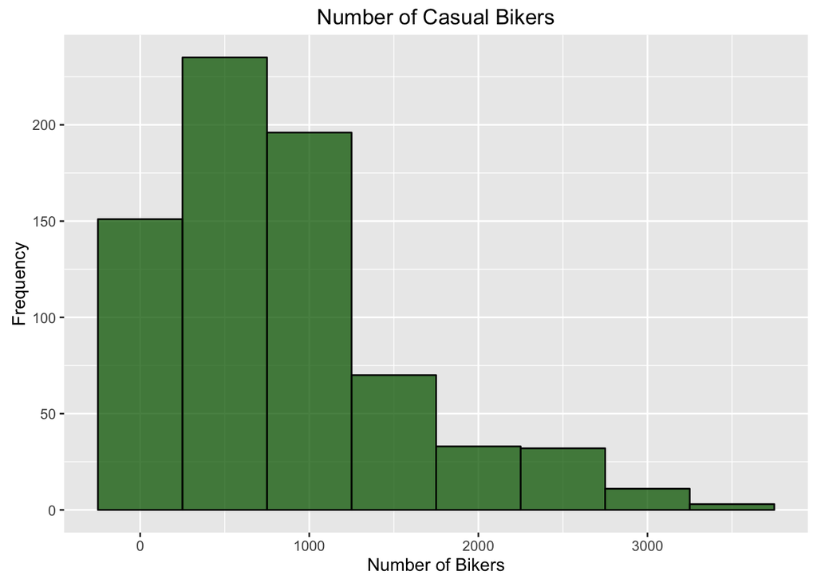

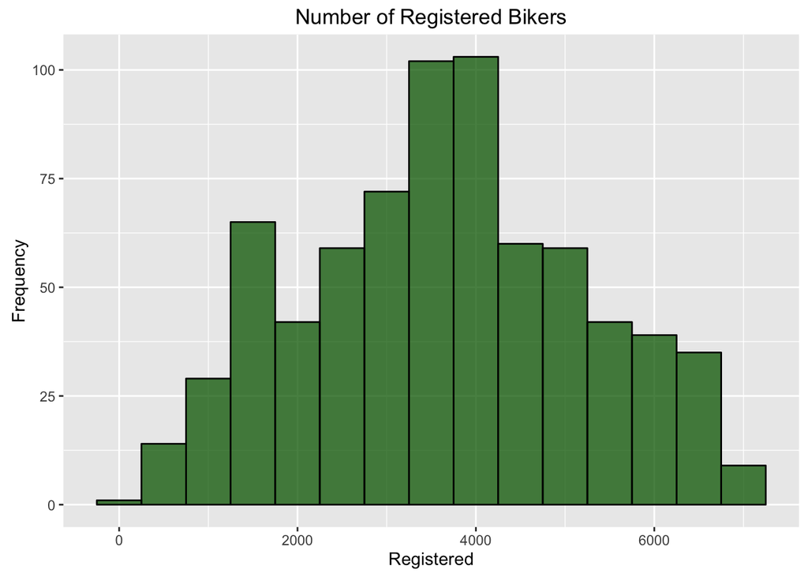

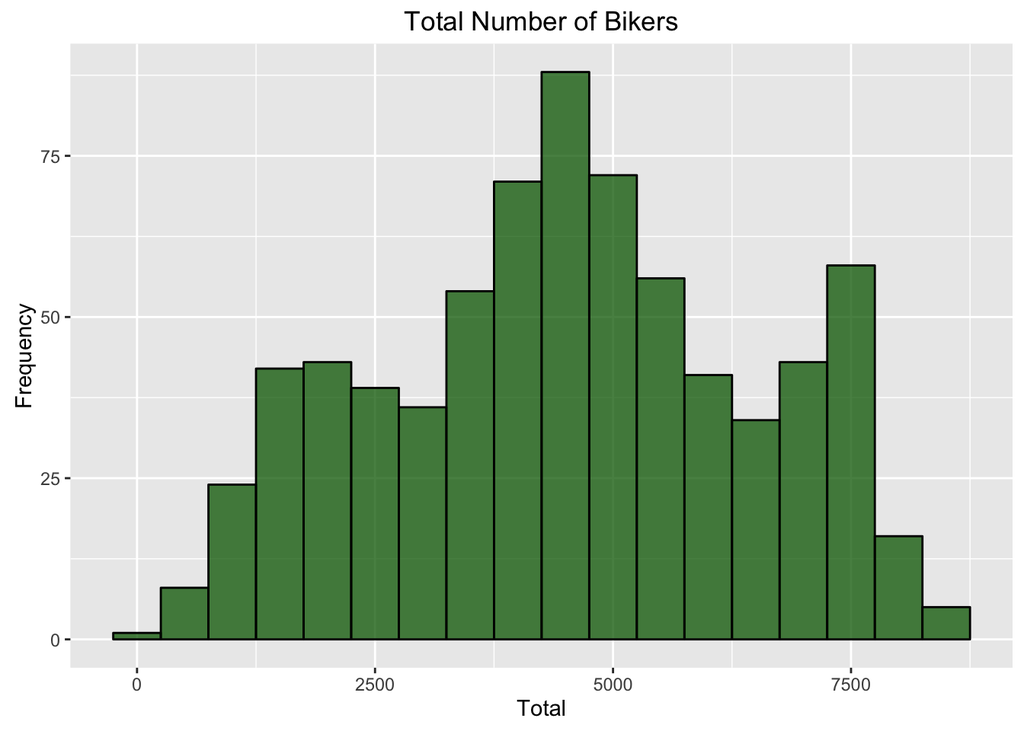

### Reducing the Dataset

The current dataset contains variables that are irrelevant to our purposes. We don’t need the record numbers (though they were useful above in identifying and evaluating possible outliers); nor do we need the specific dates because we will confine our analysis to month and season. Additionally, actual temperature and felt (“apparent”) temperature are highly correlated (see plot correlation coefficient = 0.99) so I eliminated the latter.

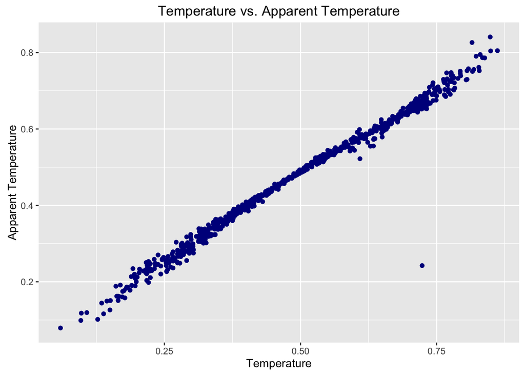

Next I looked at the relationships between “conditions” and the individual weather measurements. I used Spearman’s rank correlation tests because “conditions” is an ordinal variable, not continuous. The correlation between condition and both temperature and windspeed were non-significant (not shown). However, there was a significant relationship between humidity and condition, with a Spearman’s rho of 0.597 at the p < 2.2e-16 significance level (see below). This indicates that humidity is a pretty good substitute for “condition”.

Notice the one extreme outlier. It shows zero hunidity on a day where the weather condition is “light rain or snow”. Without this datum, the correlation would undoubtedly be higher, reinforcing the previous conclusion. [Additional testing of the power of “condition” for predicting numbers of bike riders also showed it having no better power than humidity, confirming the appropriateness of removing “condition”.]

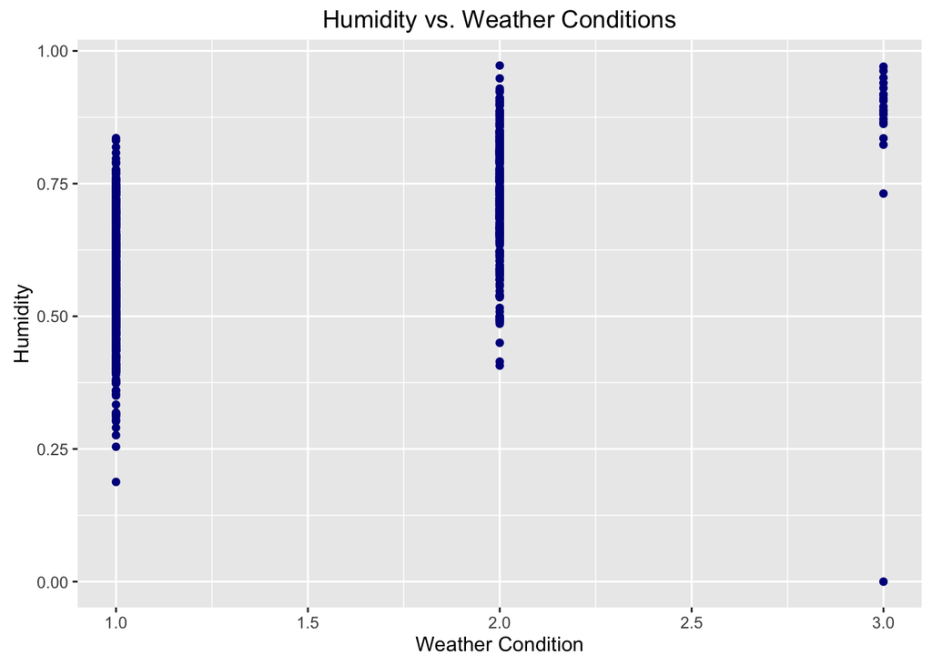

```
##
##  Spearman's rank correlation rho
##
## data:  day$conditions and day$hum
## S = 26267000, p-value < 2.2e-16
## alternative hypothesis: true rho is not equal to 0
## sample estimates:
##      rho
## 0.596532
```

Finally, I also looked at possible relationships among other weather variables and these, in fact, show various levels of correlation, generally with significance levels well below 0.01. However, in each case the R-squared values are below 0.25 indicating that the relationship has low explanitory power. Consequently, none of the remaining variables were eliminated.

Having reduced the number of variables by four, we can take a look at the summary of the non-categorical variables(below). The analyses to follow are based on this reduced set of variables.

```
##       temp              hum           windspeed           casual
##  Min.   :0.05913   Min.   :0.0000   Min.   :0.02239   Min.   :   2.0
##  1st Qu.:0.33708   1st Qu.:0.5200   1st Qu.:0.13495   1st Qu.: 315.5
##  Median :0.49833   Median :0.6267   Median :0.18097   Median : 713.0
##  Mean   :0.49538   Mean   :0.6279   Mean   :0.19049   Mean   : 848.2
##  3rd Qu.:0.65542   3rd Qu.:0.7302   3rd Qu.:0.23321   3rd Qu.:1096.0
##  Max.   :0.86167   Max.   :0.9725   Max.   :0.50746   Max.   :3410.0
##    registered       count
##  Min.   :  20   Min.   :  22
##  1st Qu.:2497   1st Qu.:3152
##  Median :3662   Median :4548
##  Mean   :3656   Mean   :4504
##  3rd Qu.:4776   3rd Qu.:5956
##  Max.   :6946   Max.   :8714
```

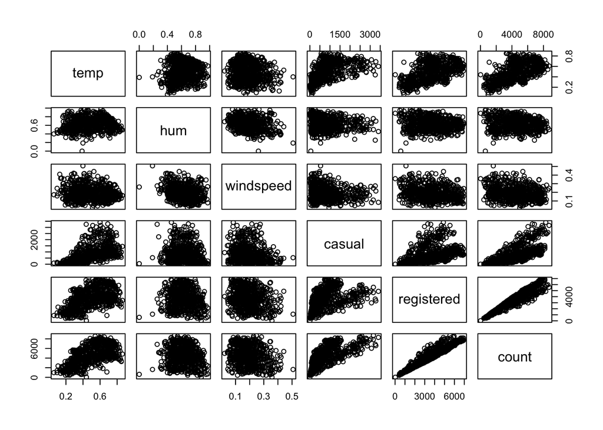

### About the Author

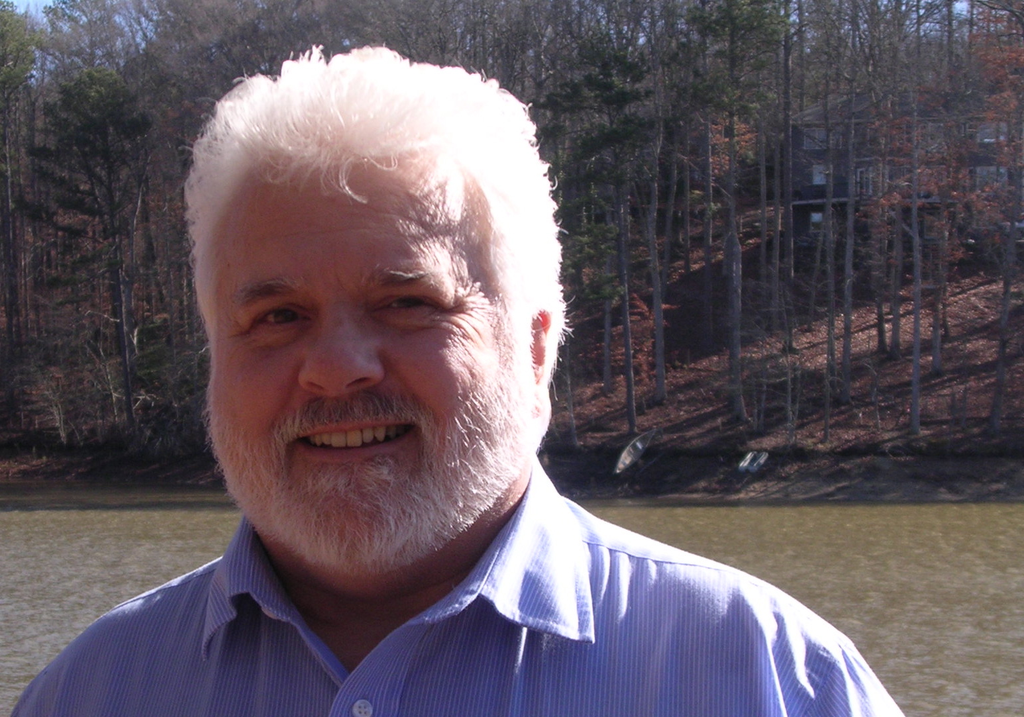

##### [Sam Skinner](https://www.linkedin.com/in/samskinnerphd) is a rambling rube in R-land, hoping to hitch a ride with fellow travelers through the R-landscape.

[figure not shown]